# Lab2

Cale Bible

2025-09-04

# Tasks

## Task 1

```r
getwd()
```

```
## [1] "C:/Users/golfe/Desktop/Applied Statistical Methods/LAB2"
```

```r
list.files()
```

```
## [1] "~$TH 4753 Laboratory 2.docx" "EPAGAS.csv"
## [3] "EPAGAS.XLS"                  "Lab2.html"
## [5] "lab2.R"                      "Lab2.Rmd"
## [7] "MATH 4753 Laboratory 2.docx" "README.md"
```

## Task 2

```r
mpg <- read.csv("EPAGAS.csv")
head(mpg)
```

```
##    MPG
## 1 36.3
## 2 41.0
## 3 36.9
## 4 37.1
## 5 44.9
## 6 36.8
```

## Task 3

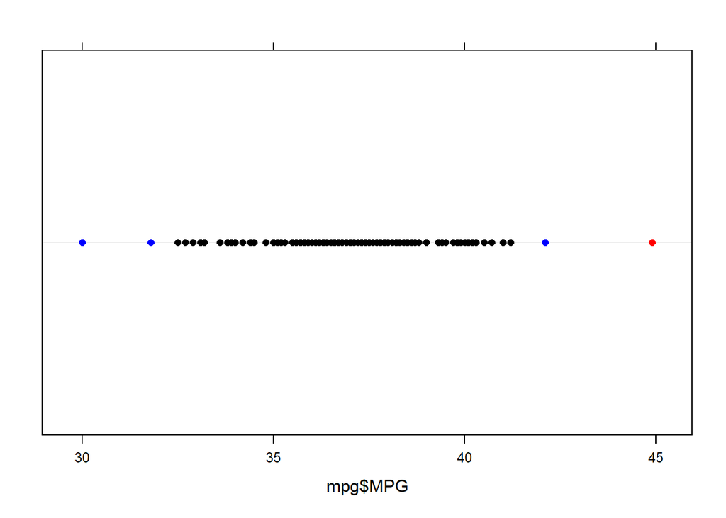

```r
mpgv <- mpg$MPG
z <- (mpgv-mean(mpgv))/sd(mpgv)
# To get potential outliers, we can plot it using a box plot.
mycol = ifelse(abs(z)>3, "Red",
        ifelse(abs(z)>=2 &abs(z)<=3,"Blue", "Black"))
mypch = ifelse(abs(z)>3, 20,
        ifelse(abs(z)>=2 &abs(z)<=3,21, 22))
library(lattice)
# Blue symbolizes possible outliers, while red symbolizes the actual outliers.
#FIXME: Add title.
dotplot(mpg$MPG,col=mycol)
```

## Task 4

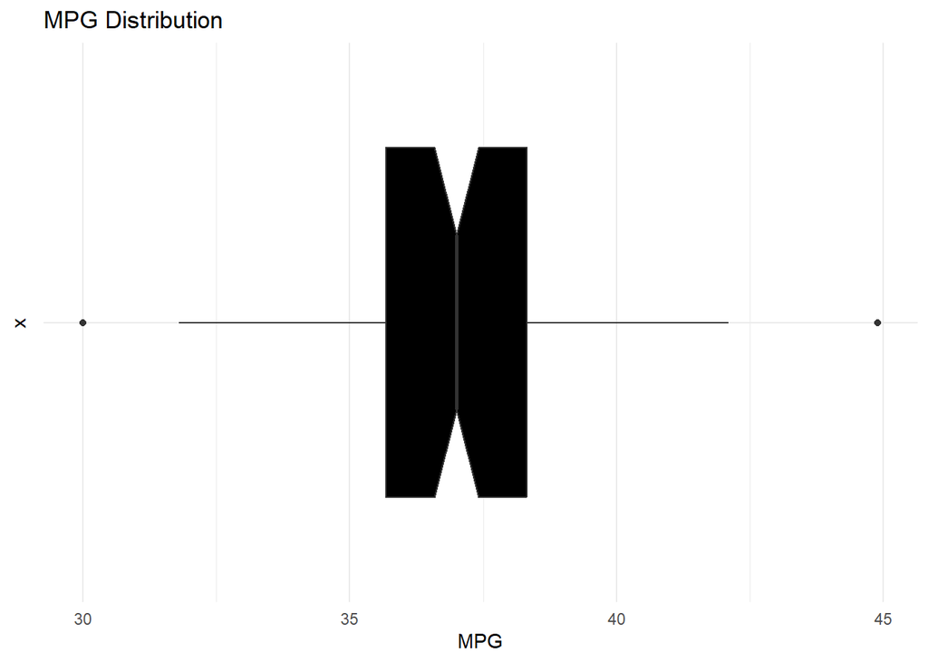

```r
library(ggplot2)
#FIXME: Add median line.
 ggplot(data = mpg, aes(x = "", y = MPG)) +
      geom_boxplot(fill="black", notch="true") +
      coord_flip() +
      labs(title="MPG Distribution") +
      theme_minimal()
```

Empirical Formula: 1. + or - one standard deviation from the mean: 68% of the data will lie there. 2. + or - two standard deviation from the mean: 95% of the data will lie there. 3. + or - three standard deviations from the mean: 99.7% of the data will lie there.

Using Chebyshev’s theorem predict the proportion of data within 2 standard deviations, we can conclude that in this data set, at least 75% of the data is between those parameters.

However, we can get a more exact percentage using r

```r
length(mpg$MPG[abs(z)<2])/length(mpg$MPG)
```

```
## [1] 0.96
```

Comparing this output to Chebyshev’s rule, we notice that his rule does agree with the data! R told us 96%, while Chebyshev’s rule told us at LEAST 75%.

For the empirical rule, we know that: 1) Within 1 standard deviation, 68% of the data is contained 2) Within 2 standard deviations, 95% of the data is contained. 3) Within 3 standard deviations, 99.7% of the data is contained.

The empirical rule gives us a MUCH closer estimate than Chebyshev’s rule in this case. It should be noted that the empiral rule can ONLY be applied to a standard bell curve.